# INE con R: descargando datos del Instituto Nacional de Estadística desde R

Primera parte: Introducción

Daniel Redondo-Sánchez - daniel.redondo.easp@juntadeandalucia.es

11-02-2019

**Con este documento vamos a aprender a descargar información del Instituto Nacional de Estadística (INE) usando R.**

## 1. Obtención de URL

El primer objetivo será el de obtener, o crear, una URL de la cual descargar los datos deseados.

### 1.1. ¿Qué es el generador de URL JSON del INE?

Para descargar datos directamente del INE podemos hacer uso del [generador de URLs JSON](https://www.ine.es/dyngs/DataLab/manual.html?cid=66), que genera una dirección URL desde la que se puede acceder a estadísticas determinadas, en formato `JSON`.

Dos enlaces nos serán muy útiles para comprender este generador, e incluso no tener que depender de él.

- [Definición de URLs](https://www.ine.es/dyngs/DataLab/manual.html?cid=47). Nos permite comprender los distintos parámetros de la URL.
- [Obtención de identificadores de objetos usando INEbase](https://www.ine.es/dyngs/DataLab/es/manual.html?cid=1259945947403). Permite reconocer el identificador de la operación estadística que se incluye en la URL.

### 1.2. Generar URL sabiendo el número de tabla

Si queremos descargar información de una URL del tipo

```
http://ine.es/jaxiT3/Tabla.htm?t=9687&L=0
```

que corresponde a “Población residente por fecha, sexo y edad”, podemos extraer de la URL el identificador de la tabla, que es `9687`, y podemos descargar la información en

```
http://servicios.ine.es/wstempus/js/ES/DATOS_TABLA/9687?nult=2&tip=AM
```

El parámetro `nult` indica que nos proporcione los n últimos datos, mientras que `tip` indica el tipo de descarga (A = amigable, M = metadatos, AM = amigable + metadatos).

### 1.3. Generar URL sabiendo que es un fichero del tipo PcAxis

Por ejemplo, si queremos descargar información de mortalidad,

```
http://ine.es/jaxi/Tabla.htm?path=/t15/p417/a2017/l0/&file=01007.px&L=0
```

es la URL de defunciones fetales tardías por causas (lista perinatal), sexo y semanas de gestación, dentro de defunciones según la Causa de Muerte 2017.

En este caso, podemos ver un `.px` dentro de la URL, lo que indica que en última instancia estamos trabajando con un fichero PcAxis, el formato que usa el INE para editar y publicar sus datos.

El identificador de la tabla se creará usando la parte de la URL `path=/t15/p417/a2017/l0/&file=01007.px` y extrayendo `path=` y `&file=`:

```
/t15/p417/a2017/l0/01007.px
```

La URL deseada será entonces:

```
http://servicios.ine.es/wstempus/js/ES/DATOS_TABLA/t15/p417/a2017/l0/01007.px?tip=AM
```

## 2. Primera descarga

### 2.1. Primeros pasos

Cargamos los paquetes necesarios:

```r
library(httr)
library(rlist)
library(dplyr)
library(data.table)
```

```r
url <- "http://servicios.ine.es/wstempus/js/ES/DATOS_TABLA/t15/p417/a2017/l0/01007.px?tip=AM"
```

Usamos la función `GET` del paquete `httr`, usando como único parámetro la URL obtenida en el paso anterior.

```r
defunciones_json <- GET(url)
```

La variable `status_code` indica el éxito (o no) de la petición realizada. Un código que empieza por 2, o 3, suele indicar que la petición ha sido exitosa. Si el `status_code` comienza por 4, es que hay un problema en tu código (p.e. 404: la página no encuentra lo que solicitas), mientras que si comienza por 5, el problema está en la página web.

```r
defunciones_json$status_code
```

```
## [1] 200
```

Podemos usar `http_type` para conocer el tipo de información que hemos obtenido.

```r
http_type(defunciones_json)
```

```
## [1] "application/json"
```

### 2.2. Pre-procesamiento

La información debe ser pre-procesada antes de poder ser usada. Vemos la información cruda:

```r
defunciones_json
```

```
## Response [http://servicios.ine.es/wstempus/js/ES/DATOS_TABLA/t15/p417/a2017/l0/01007.px?tip=AM]
##   Date: 2021-06-15 10:56
##   Status: 200
##   Content-Type: application/json;charset=UTF-8
##   Size: 1.45 MB
## [{"Nombre":"01-93 I-XXII.Todas las causas, Ambos sexos, Total", "MetaData":[{...
## , "Nombre":"01-93 I-XXII.Todas las causas", "Codigo":"0193ixxiitodaslascausas"}
## ,{"Variable":{"Nombre":"sexo", "Codigo":"sexo"}
## , "Nombre":"Ambos sexos", "Codigo":"ambossexos"}
## ,{"Variable":{"Nombre":"semanas de gestación", "Codigo":"semanasdegestacion"}
## , "Nombre":"Total", "Codigo":"total"}
## ]
## , "Data":[{"Valor":1274.0}
## ]
## }
## ...
```

La función `content` extrae el contenido de lo solicitado. Vemos las primeras dos componentes del contenido:

```r
defunciones_contenido <- content(defunciones_json)
head(defunciones_contenido, 2)
```

```
## [[1]]
## [[1]]$Nombre
## [1] "01-93 I-XXII.Todas las causas, Ambos sexos, Total"
##
## [[1]]$MetaData
## [[1]]$MetaData[[1]]
## [[1]]$MetaData[[1]]$Variable
## [[1]]$MetaData[[1]]$Variable$Nombre
## [1] "causas (lista perinatal)"
##
## [[1]]$MetaData[[1]]$Variable$Codigo
## [1] "causaslistaperinatal"
##
##
## [[1]]$MetaData[[1]]$Nombre
## [1] "01-93 I-XXII.Todas las causas"
##
## [[1]]$MetaData[[1]]$Codigo
## [1] "0193ixxiitodaslascausas"
##
##
## [[1]]$MetaData[[2]]
## [[1]]$MetaData[[2]]$Variable
## [[1]]$MetaData[[2]]$Variable$Nombre
## [1] "sexo"
##
## [[1]]$MetaData[[2]]$Variable$Codigo
## [1] "sexo"
##
##
## [[1]]$MetaData[[2]]$Nombre
## [1] "Ambos sexos"
##
## [[1]]$MetaData[[2]]$Codigo
## [1] "ambossexos"
##
##
## [[1]]$MetaData[[3]]
## [[1]]$MetaData[[3]]$Variable
## [[1]]$MetaData[[3]]$Variable$Nombre
```

[output cut: 65 more lines]

```
## [1] "semanasdegestacion"
##
##
## [[2]]$MetaData[[3]]$Nombre
## [1] "Menos de 28 semanas"
##
## [[2]]$MetaData[[3]]$Codigo
## [1] "menosde28semanas"
##
##
##
## [[2]]$Data
## [[2]]$Data[[1]]
## [[2]]$Data[[1]]$Valor
## [1] 196
```

Ya podríamos acceder a algunos datos, como por ejemplo:

```r
defunciones_contenido[[1]]$Nombre
```

```
## [1] "01-93 I-XXII.Todas las causas, Ambos sexos, Total"
```

```r
defunciones_contenido[[1]]$MetaData[[1]]$Codigo
```

```
## [1] "0193ixxiitodaslascausas"
```

```r
defunciones_contenido[[1]]$Data[[1]]$Valor
```

```
## [1] 1274
```

Pero esto no es lo ideal, así que seguimos procesando. Utilizaremos el paquete `rlist` de manera iterativa para extraer los datos y metadatos de la información descargada, y formar así un data.frame.

```r
n <- length(defunciones_contenido)

for(i in 1:n){
   dato.i <- defunciones_contenido[[i]]
   defunciones.i <- list.select(dato.i$Data, Valor) %>% list.stack %>%
         cbind(codigo = dato.i$MetaData[[1]]$Codigo) %>%
         cbind(sexo = dato.i$MetaData[[2]]$Codigo) %>%
         cbind(s_gest = dato.i$MetaData[[3]]$Codigo)
   ifelse(i == 1,
          defunciones <- defunciones.i,
          defunciones <- rbindlist(list(defunciones, defunciones.i)))
}

head(defunciones)
```

```
##    Valor                  codigo       sexo           s_gest
## 1:  1274 0193ixxiitodaslascausas ambossexos            total
## 2:   196 0193ixxiitodaslascausas ambossexos menosde28semanas
## 3:   229 0193ixxiitodaslascausas ambossexos   de28a31semanas
## 4:   355 0193ixxiitodaslascausas ambossexos   de32a36semanas
## 5:   322 0193ixxiitodaslascausas ambossexos   de37a41semanas
## 6:     0 0193ixxiitodaslascausas ambossexos    42semanasymas
```

También podríamos haber descargado las etiquetas de las variables, en lugar de los códigos:

```r
n <- length(defunciones_contenido)

for(i in 1:n){
   dato.i <- defunciones_contenido[[i]]
   defunciones.i <- list.select(dato.i$Data, Valor) %>% list.stack %>%
         cbind(codigo = dato.i$MetaData[[1]]$Nombre) %>%
         cbind(sexo = dato.i$MetaData[[2]]$Nombre) %>%
         cbind(s_gest = dato.i$MetaData[[3]]$Nombre)
   ifelse(i == 1,
          defunciones <- defunciones.i,
          defunciones <- rbindlist(list(defunciones, defunciones.i)))
}

head(defunciones)
```

```
##    Valor                        codigo        sexo              s_gest
## 1:  1274 01-93 I-XXII.Todas las causas Ambos sexos               Total
## 2:   196 01-93 I-XXII.Todas las causas Ambos sexos Menos de 28 semanas
## 3:   229 01-93 I-XXII.Todas las causas Ambos sexos  De 28 a 31 semanas
## 4:   355 01-93 I-XXII.Todas las causas Ambos sexos  De 32 a 36 semanas
## 5:   322 01-93 I-XXII.Todas las causas Ambos sexos  De 37 a 41 semanas
## 6:     0 01-93 I-XXII.Todas las causas Ambos sexos    42 semanas y más
```

### 2.3. Ejemplo de uso

Podemos hacer un gráfico con los datos descargados:

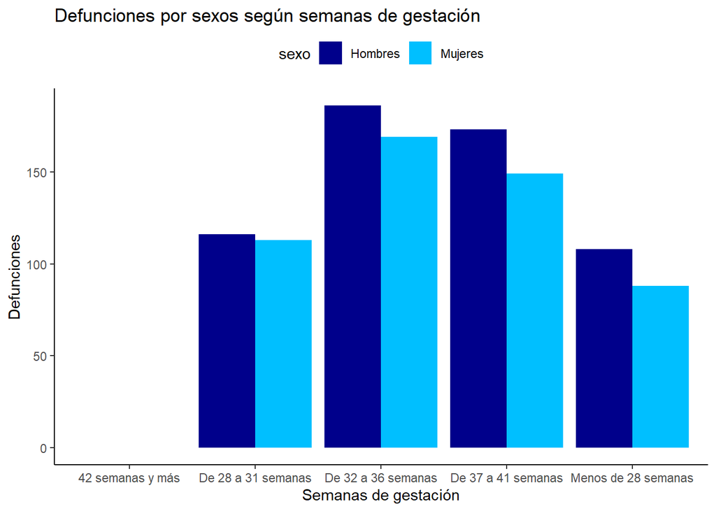

```r
library(ggplot2)

defunciones %>%
  filter(
    codigo == "01-93 I-XXII.Todas las causas",
    sexo != "Ambos sexos",
    ! s_gest %in% c("Total", "No consta")
  ) %>%
  ggplot(aes(x = s_gest, y = Valor, fill = sexo)) +
  scale_fill_manual(values = c("darkblue", "deepskyblue")) +
  geom_bar(stat = "identity", position = "dodge") +
  ylab("Defunciones") +
  xlab("Semanas de gestación") +
  ggtitle("Defunciones por sexos según semanas de gestación") +
  theme_classic() +
  theme(legend.position = "top")
```